# RR_Markdown: Reproducible Research Project 1

Nirmal Ghimire

9/15/2020

## Checking Directory and Setting Desired Directory

```r
getwd()
```

```
## [1] "C:/Users/nirma/Documents/GitHub/RepData_PeerAssessment1"
```

```r
setwd("C:/Users/nirma/Documents/GitHub/RepData_PeerAssessment1")
```

## Invoking Required Libraries and Resources

```r
require(lubridate)
require(dplyr)
```

```r
require(ggplot2)
library(scales)
require(ggthemes)
require(RColorBrewer)
```

## Reading the data file. Data have been already downloaded,unzipped and saved in the local directory

```r
mydata<-read.csv('activity.csv')
```

Getting to Know Your Data:

```r
head(mydata)
```

```
##   steps       date interval
## 1    NA 2012-10-01        0
## 2    NA 2012-10-01        5
## 3    NA 2012-10-01       10
## 4    NA 2012-10-01       15
## 5    NA 2012-10-01       20
## 6    NA 2012-10-01       25
```

```r
summary(mydata)
```

```
##      steps            date              interval
##  Min.   :  0.00   Length:17568       Min.   :   0.0
##  1st Qu.:  0.00   Class :character   1st Qu.: 588.8
##  Median :  0.00   Mode  :character   Median :1177.5
##  Mean   : 37.38                      Mean   :1177.5
##  3rd Qu.: 12.00                      3rd Qu.:1766.2
##  Max.   :806.00                      Max.   :2355.0
##  NA's   :2304
```

```r
class(mydata)
```

```
## [1] "data.frame"
```

```r
names(mydata)
```

```
## [1] "steps"    "date"     "interval"
```

## Setting date

```r
mydata$date<-as.Date(mydata$date)
```

## 1. Calculating total steps taken per day and making histogram

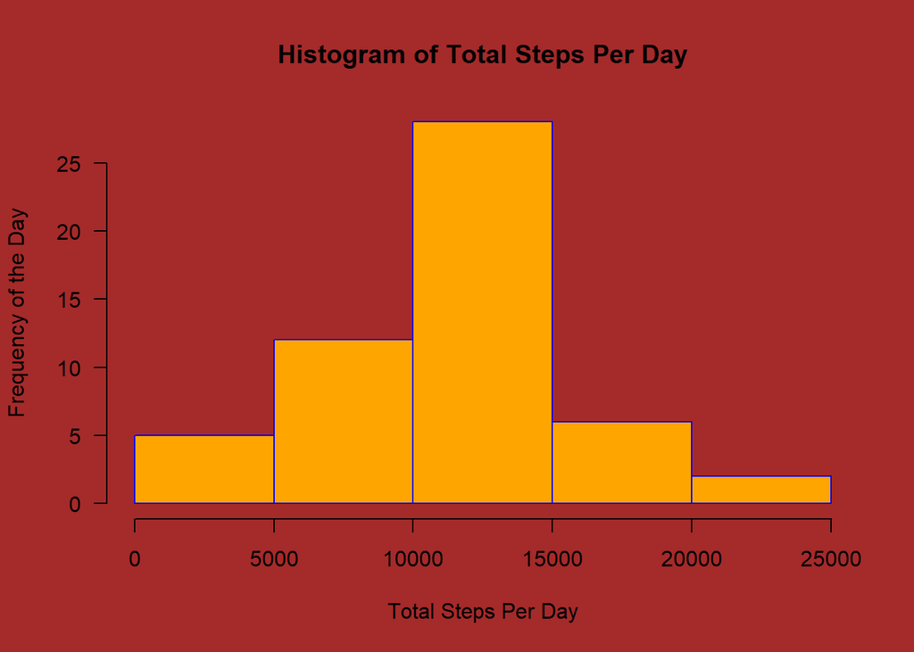

```r
dailysteps<-aggregate(steps~date,mydata,FUN=sum, na.rm=TRUE)
par(bg='brown')
hist(dailysteps$steps,
     main="Histogram of Total Steps Per Day",
     xlab="Total Steps Per Day",
     ylab="Frequency of the Day",
     border="blue",
     col="orange",
     las=1)
```

## 2.Calculating and reporting Mean and the Median of total steps per day

Mean:

```r
dailymean<-mean(dailysteps$steps)
dailymean
```

```
## [1] 10766.19
```

Median:

```r
dailymedian<-median(dailysteps$steps)
dailymedian
```

```
## [1] 10765
```

## 3. What is the average daily activity pattern?

1. making a time series plot (i.e., type=“1”)of the 5-minute interval (x-axis)and the average number of steps taken, averaged across all days (y-axis): i. quickly checking dataset

```r
names(mydata)
```

```
## [1] "steps"    "date"     "interval"
```

2. Calculating Interval Steps

```r
intervalsteps<-aggregate(steps~interval,data=mydata,mean,na.rm=TRUE)
```

3. plotting the interval steps

[figure not shown]

```r
par(bg='grey')
plot(steps~interval,data=intervalsteps, type='l',
     main="Average Interval Frequency",
     xlab="Average Steps",
     ylab="Interval Frequency",
          cex.lab=1,
          col="blue")
```

4. Which 5-minute interval, on average across all the days in the dataset contains the maximum number of steps

```r
maxstepsinterval<-intervalsteps[which.max(intervalsteps$steps),]$interval
maxstepsinterval
```

```
## [1] 835
```

## 4. Dealing with the Missing Values

1. Calculate and report the total missing values in the dataset

```r
totalmissing<-sum(is.na(mydata$steps))
totalmissing
```

```
## [1] 2304
```

2. Devise a strategy for filling in all missing values in the data set using mean

###### i. Imputing NAs

```r
NAcolumn<-ifelse(is.na(mydata$steps),round(intervalsteps$steps[match
                  (mydata$interval,intervalsteps$interval)],0),mydata$steps)
```

###### ii. New dataset ‘imputeddata’

```r
imputeddata<-data.frame(steps=NAcolumn,interval=mydata$interval,date=mydata$date)
```

###### iii. Quick checking

```r
head(imputeddata,n=10)
```

```
##    steps interval       date
## 1      2        0 2012-10-01
## 2      0        5 2012-10-01
## 3      0       10 2012-10-01
## 4      0       15 2012-10-01
## 5      0       20 2012-10-01
## 6      2       25 2012-10-01
## 7      1       30 2012-10-01
## 8      1       35 2012-10-01
## 9      0       40 2012-10-01
## 10     1       45 2012-10-01
```

3. Making a histogram of the total steps per day and calculating and reporting the mean and median

```r
dailyimputed<-aggregate(imputeddata$steps,list(imputeddata$date),FUN=sum)
colnames(dailyimputed)<-c("Date","Steps")
```

###### Plotting a histogram

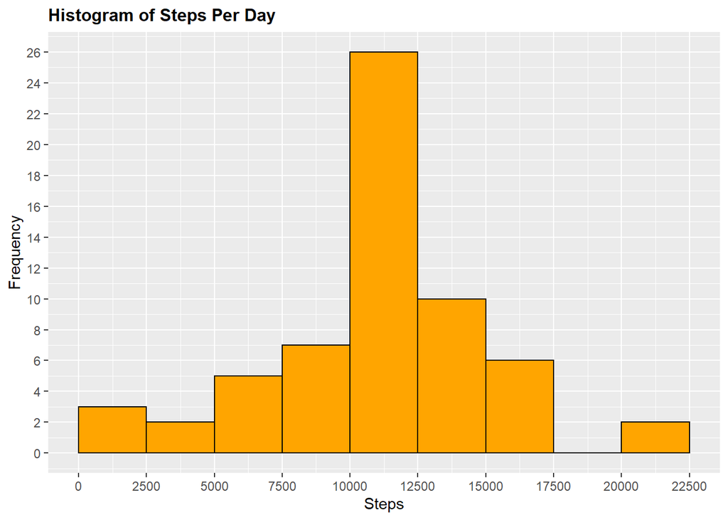

```r
hgram<-ggplot(dailyimputed,aes(Steps))
hgram+geom_histogram(boundary=0,binwidth = 2500,col="black",fill="orange")+
  ggtitle("Histogram of Steps Per Day")+xlab("Steps")+ylab("Frequency")+
  theme(plot.title=element_text(face="bold",size=12))+scale_x_continuous(breaks=
                  seq(0,25000,2500))+scale_y_continuous(breaks = seq(0,26,2))
```

###### i. Daily average steps after imputation

```r
mean(dailyimputed$Steps)
```

```
## [1] 10765.64
```

###### ii. Daily median steps after imputation

```r
median(dailyimputed$Steps)
```

```
## [1] 10762
```

## 4. Are there differnces in activity patterns between weekdays and weekends?

###### i. Creating a new factor variable in dataset with two levels=“weekday” and “weekend”

```r
imputeddata$exactdate<-as.Date(imputeddata$date,format="%Y-%m-%d")
```

###### ii. New variable with weekday

```r
imputeddata$weekday<-weekdays(imputeddata$exactdate)
```

###### iii. Introducing weekend

```r
imputeddata$daytype<-ifelse(imputeddata$weekday=='Saturday'|
                            imputeddata$weekday=='Sunday','weekend','weekday')
```

###### iv. checking if it works

```r
head(imputeddata, n=5)
```

```
##   steps interval       date  exactdate weekday daytype
## 1     2        0 2012-10-01 2012-10-01  Monday weekday
## 2     0        5 2012-10-01 2012-10-01  Monday weekday
## 3     0       10 2012-10-01 2012-10-01  Monday weekday
## 4     0       15 2012-10-01 2012-10-01  Monday weekday
## 5     0       20 2012-10-01 2012-10-01  Monday weekday
```

## 5. Creating two time series plot of the 5-minute interval (x) and the average number of steps taken averaged across weekday days or weekend days (y)

```r
stepsPerTime<-aggregate(steps~interval+daytype,data=imputeddata,FUN=mean,
                        na.action = na.omit)
stepsPerTime$time<-intervalsteps$interval/100
```

###### i. Drawing Line Plots

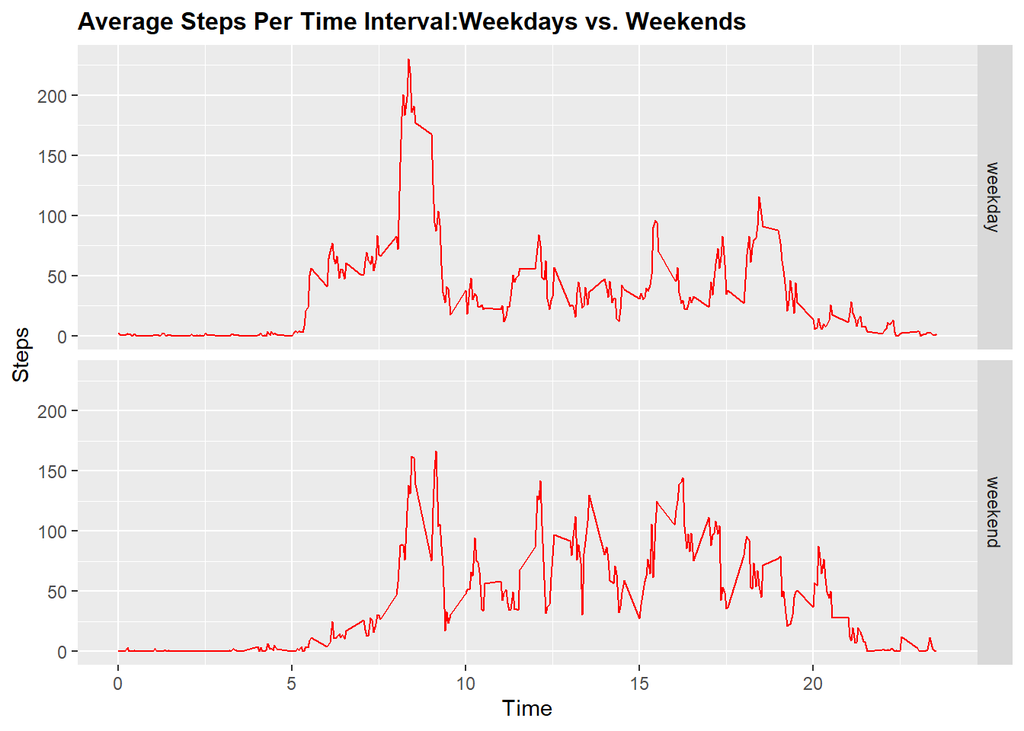

```r
Lplot<-ggplot(stepsPerTime,aes(time,steps))
Lplot+geom_line(col="red")+ggtitle("Average Steps Per Time Interval:Weekdays vs. Weekends")+xlab("Time")+ylab("Steps")+theme(plot.title=element_text(
    face="bold",size=12))+facet_grid(daytype~.)
```